# JWacPrez

## Basic Paper Outline

-Section 1: Intro  
-Basic question: Does US distraction due to wars, particularly in the Middle East lead to adverse outcomes in the rest of the world.  
-Contributions:  
1. Novel and superior measure of state affinity/preferences/closeness  
2. Novel measure of US distraction  
3. Findings about how US distraction leads states to cozy up/distance themselves from China  
-Can use US withdrawal from Afghanistan and implications for US/China competition as an easy hook  
-Understand that requires two things, neither of which has really gotten traction in IR (lit reviewy stuff)  
1. Measure of US distraction  
2. Measure of state preferences  
-Section 2: Our stylized argument/hypotheses etc. -Two opposing arguments  
-1) Limited resources/attention, distraction allows for trouble elsewhere  
-2) Credibility/resolve -- US doing costly things in Middle East should cause us to update (positively) that theyre willing to do costly things elsewhere  
-Section 3: Data and Methods  
-Measuring Distraction  
-Measuring State preferences  
-Section 4: Downstream stuff  
-Closeness to China as a DV, main findings support argument 2  
-Notably heterogeneous effect -- as US becomes more distracted, it seems like most states move away from China, but Chinas neighbors do the opposite  
-Section 5: Highlight cool results

## Our Major Measures in More Detail

1. Measure of state affinity. -Drawn from latent factor model.  
   -Basic idea of latent factor model is a model that can account for 3 levels of network dependency  
   -1st order deps -- certain actors are more/less popular than others in all their interactions  
   -2nd order deps -- reciprocality is a thing  
   -3rd order deps -- homophily and stochastic equivalence (the two that most network models arent able to get at)  
   -Gets at 3rd order dependencies using "multiplicative effect" that relies on singular value decomposition.  
   -So we run LFM using a set of economic relations as our dependent variable, and extract this multiplicative effect, as our main measure of state affinity.  
   -Higher values of it are associated with states being more likely to engage in these types of economic cooperation, lower values less likely  
   -We then difference it to get the year to year change in state affinity.
2. Measure of US distraction.  
   -Take data on US military casualties and mideast commitments, and run a PCA  
   -Alternative measure based on foreign troop commitments and US defense spending

## Model Setup

Unit of observation: country year from 1992-2019  
DV: Change in our affinity measure for the country to China  
Key IV: lagged measure of US distraction  
Controls: Polity, Population, Distance to Beijing, Bailey/Voeten/Strezhnev Ideal Point Distance, GDP  
Random Effects: By region (using UNs 23 regions)

## Results

Main Models: Models with region random effects

|  | mu | sd |
| --- | --- | --- |
| (Intercept) | 0.124 | 0.073 |
| USf1.l1 | -0.044 | 0.005 |
| polity.l1 | -0.002 | 0.001 |
| GDP.l1 | -0.026 | 0.004 |
| pop.l1 | 0.028 | 0.006 |
| beijDist | 0.008 | 0.012 |
| IdealPointDistance | 0.024 | 0.007 |

|  | mu | sd |
| --- | --- | --- |
| (Intercept) | 0.133 | 0.072 |
| USf2.l1 | -0.036 | 0.005 |
| polity.l1 | -0.003 | 0.001 |
| GDP.l1 | -0.030 | 0.004 |
| pop.l1 | 0.031 | 0.006 |
| beijDist | 0.009 | 0.013 |
| IdealPointDistance | 0.032 | 0.007 |

|  | mu | sd |
| --- | --- | --- |
| (Intercept) | 0.152 | 0.071 |
| polity.l1 | -0.001 | 0.001 |
| GDP.l1 | -0.024 | 0.004 |
| pop.l1 | 0.025 | 0.006 |
| beijDist | 0.008 | 0.009 |
| IdealPointDistance | 0.028 | 0.007 |

|  | mu | sd |
| --- | --- | --- |
| (Intercept) | 0.187 | 0.071 |
| polity.l1 | -0.002 | 0.001 |
| GDP.l1 | -0.029 | 0.004 |
| pop.l1 | 0.030 | 0.006 |
| beijDist | 0.011 | 0.010 |
| IdealPointDistance | 0.034 | 0.007 |

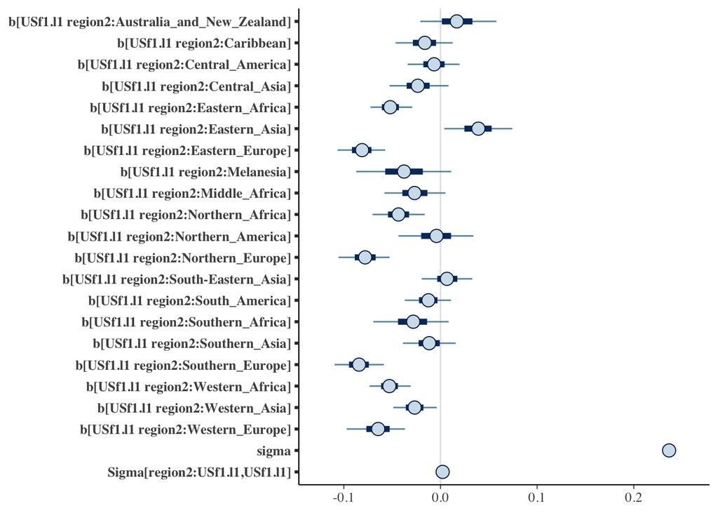

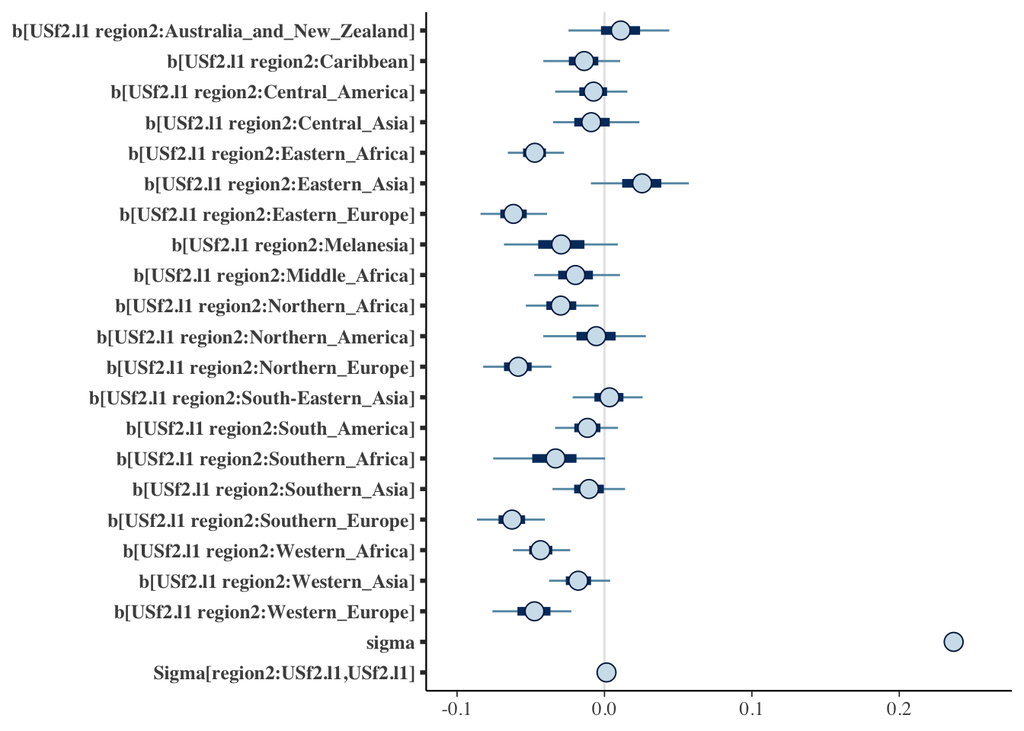

Main Models: Models with Country random effects

|  | mu | sd |
| --- | --- | --- |
| (Intercept) | 0.059 | 0.095 |
| USf1.l1 | -0.043 | 0.006 |
| polity.l1 | -0.001 | 0.001 |
| GDP.l1 | -0.029 | 0.006 |
| pop.l1 | 0.036 | 0.008 |
| beijDist | 0.008 | 0.006 |
| IdealPointDistance | 0.023 | 0.008 |

|  | mu | sd |
| --- | --- | --- |
| (Intercept) | 0.124 | 0.104 |
| USf2.l1 | -0.034 | 0.005 |
| polity.l1 | -0.002 | 0.001 |
| GDP.l1 | -0.038 | 0.006 |
| pop.l1 | 0.044 | 0.008 |
| beijDist | 0.010 | 0.007 |
| IdealPointDistance | 0.037 | 0.008 |

|  | mu | sd |
| --- | --- | --- |
| (Intercept) | 0.262 | 0.105 |
| polity.l1 | 0.000 | 0.001 |
| GDP.l1 | -0.046 | 0.007 |
| pop.l1 | 0.048 | 0.008 |
| beijDist | 0.011 | 0.007 |
| IdealPointDistance | 0.047 | 0.008 |

|  | mu | sd |
| --- | --- | --- |
| (Intercept) | 0.283 | 0.109 |
| polity.l1 | -0.001 | 0.001 |
| GDP.l1 | -0.050 | 0.007 |
| pop.l1 | 0.052 | 0.008 |
| beijDist | 0.012 | 0.008 |
| IdealPointDistance | 0.049 | 0.008 |

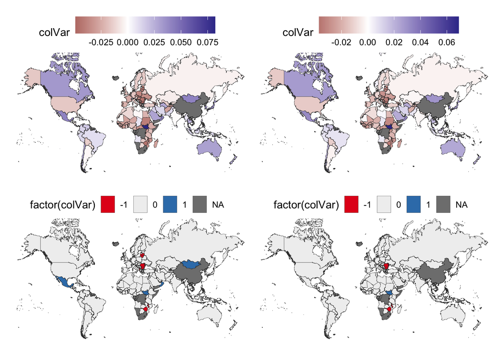

Lasso using all 3 measures of US distraction and region fixed effects.

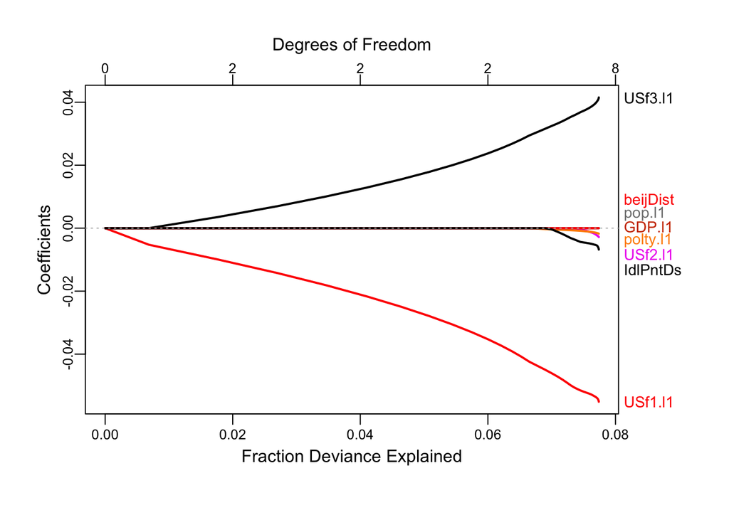

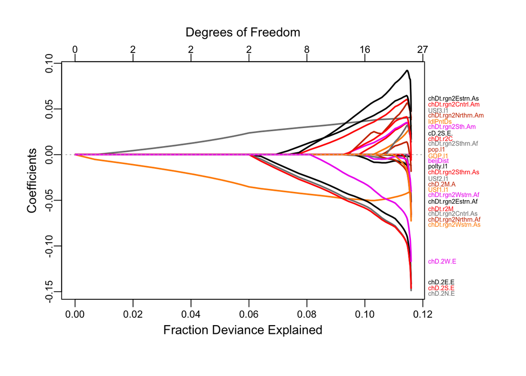

## Next Steps

1. Get data on natural resource endowments
2. Rerun models seeing if US distraction metrics are conditioned by
   1. Natural resource endowment
   2. Regime type (polity autoc/anoc/democ)
   3. Strategic concerns (geography I guess)